# Excercise 3

TMA4300 Computer intensive statistical methods Spring 2021

Johan Fredrik Agerup

Arne Rustad

21 april, 2021

# Problem A

## Comparing AR(2) parameter estimators using resampling of residuals

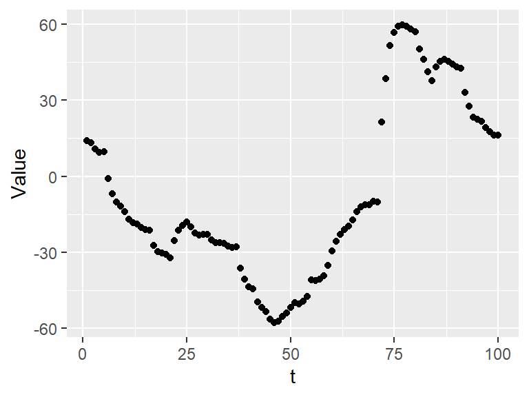

Plot of the non-Gaussian time series.

```r
source("probAdata.R")
df_OG_data = data.frame(t = seq(1, 100), Value = data3A$x)
ggplot(data = df_OG_data, aes(x = t, y = Value)) + geom_point()
```

We consider an AR(2) model which is specified by the relation:

$$\begin{equation}\label{AR2}
x_t = \beta_1 x_{t-1} + \beta_2 x_{t-2} + e_t,
\end{equation}$$

where $e_t$ are iid with zero mean and constant variance. Deriving the two estimators for the residuals we want to compare, we are going to use the the least sum of squared residuals (LS) and least sum of absolute residuals (LA). The minimisers are obtained by minimising the following loss functions with respect to $\mathbf{\beta}$:

$$\begin{align}
Q_{LS} (\mathbf{x}) = \sum_{t=3}^{T} ( x_t - \beta_1 x_{t-1} - \beta_2 x_{t-2} )^2\\
Q_{LA} (\mathbf{x}) = \sum_{t=3}^{T} |x_t - \beta_1 x_{t-1} - \beta_2 x_{t-2}|
\end{align}$$

We denote the minimisers by $\mathbf{\beta}_{LS}$ and $\mathbf{\beta}_{LA}$ (calculated by the script ARp.beta.est). We then define the estimated residuals to be:

$$\begin{equation}\label{estimated_residuals}
\hat{e}_t = x_t -\hat{\beta}_1x_{t-1} -\hat{\beta}_2 x_{t-2}
\end{equation}$$

for $t = 3, . . . , T$, and let $\bar{e}$ be the mean of these. The $\hat{e}_t$ can be re-centered to have mean zero by defining $\hat{\epsilon}_t = \hat{e}_t -\bar{e}$. (Results for $\hat{\epsilon}_t$ obtained by LS and LA can be calculated with ARp.resid).

## A.1

### 1.1 Use the residual resampling bootstrap method to evaluate the relative performance of the two parameter estimators.

In order to do the resampling we have to pick random consecutive pairs from the original data. In this case where $\mathbf{x} = \{x_1, \dots, x_{100} \}$ we pick such that all possible pairs is given by:

$$\begin{equation}\label{all_possible_consecutive_pairs}
\begin{pmatrix}
x_1 & x_2 & x_3 & \dots & x_{99}\\
x_2 & x_3 & x_4 & \dots & x_{100}
\end{pmatrix}
\end{equation}$$

```r
source("probAhelp.R", local = knitr::knit_global())
minisers_ar2 = ARp.beta.est(x = data3A$x, p = 2)
eps_residuals_LS = ARp.resid(x = data3A$x, beta = minisers_ar2$LS)
eps_residuals_LA = ARp.resid(x = data3A$x, beta = minisers_ar2$LA)

#initialise values for x1 and x2
#by picking a random consecutive subsequence from the data

"Agenda:
- det er ikke bare 50 mulige par, men 99
- eks: x1x2, x2x3, x3x4, ..."
```

```
## [1] "Agenda:\n- det er ikke bare 50 mulige par, men 99\n- eks: x1x2, x2x3, x3x4, ..."
```

```r
sample_consecutive = function(x){
  #set seed for reproducability
  #set.seed(2021)
  idx = sample(seq(1,length(x)-1), size = 1, replace = FALSE)
  return(x[idx:(idx+1)])
  # x_reshaped = matrix(unlist(t(x)), byrow=T, 2*length(x)-2, 2)
  # print(x_reshaped)
  # x_sample_pair = x_reshaped[idx,]
  # return(x_sample_pair)
}

x1x2_sample1 = sample_consecutive(x = data3A$x)
print(x1x2_sample1)
```

```
## [1] 37.55171 42.97230
```

To do a resampling, initialise values for $x_1$ and $x_2$ by picking a random consecutive subsequence from the data.

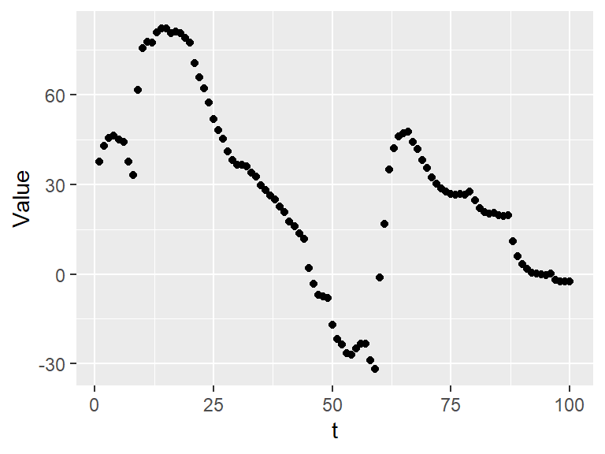

```r
calc_x_LS = ARp.filter(x0 = x1x2_sample1,
                       beta = minisers_ar2$LS,
                       e = sample(eps_residuals_LS, size=length(eps_residuals_LS), replace=TRUE))
df_samples_LS = data.frame(t = seq(1,100), Value = calc_x_LS)
ggplot(data = df_samples_LS) + geom_point(aes(x = t, y = Value))
```

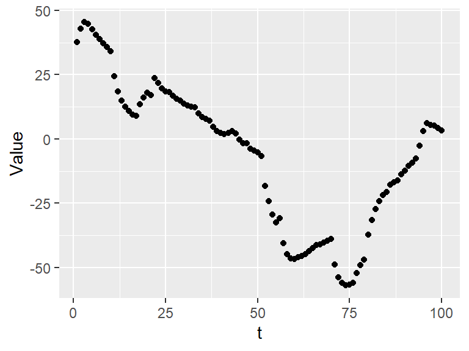

```r
calc_x_LA = ARp.filter(x0 = x1x2_sample1,
                       beta = minisers_ar2$LA,
                       e = sample(eps_residuals_LA, size=length(eps_residuals_LA), replace=TRUE))
df_samples_LA = data.frame(t = seq(1,100), Value = calc_x_LA)
ggplot(data = df_samples_LA) + geom_point(aes(x = t, y = Value))
```

### 1.2 Specifically, estimate the variance and bias of the two estimators.

The two parameters of interest are $\mathbf{\beta}$ and the estimators for the minimisers is $\hat{\mathbf{\beta}}_{LS}$ and $\hat{\mathbf{\beta}}_{LA}$ with respect to the loss functions $Q_{LS}$ and $Q_{LA}$. We want to estimate the variance of the estimators. This is given by $\mathrm{Var}(\hat{\mathbf{\beta}}_{LS})$ and $\mathrm{Var}(\hat{\mathbf{\beta}}_{LA})$ where we use the plug-in principle to estimate the variance. The following algorithm for calculating the variance and bias for the estimators in the residual bootstrapping is then given by:

1. Generate $B$ bootstrap samples $x^{1*}, \dots, x^{B*}$.
2. Evaluate the corresponding parameter estimates: $\hat{\beta}^{*}(b) = s(x^{b*}), b = 1,2, \dots, B$.
3. Estimate the variance by:

$$\begin{equation}
\hat{\mathrm{Var}}_B = \frac{ \sum_{b=1}^B \left( \hat{\beta}^{*}(b) - \hat{\beta}^{*}(\cdot) \right)^2 }{B-1},
\end{equation}$$
where:
$$\begin{equation}
\hat{\beta}^{*}(\cdot) \equiv \frac{1}{B}\sum_{b=1}^B \hat{\beta}^{*}(b)
\end{equation}$$

4. Calculate bias for LS:
   $$\begin{equation}
   \mathrm{bias}(\hat{\beta}_{LS}) = \hat{\beta}_{LS}^{*}(\cdot) - t(\hat{F}),
   \end{equation}$$
   where $\hat{\beta}_{LS}^{*}(\cdot)$ represents the bootstrap mean of the beta estimator.
5. Calculate bias for LA:
   $$\begin{equation}
   \mathrm{bias}(\hat{\beta}_{LA}) = \hat{\beta}_{LA}^{*}(\cdot) - t(\hat{F}),
   \end{equation}$$
   where $\hat{\beta}_{LA}^{*}(\cdot)$ represents the bootstrap mean of the beta estimator and $t(\hat{F})$ is the calculated betas from the original data.

```r
# bootstrap resampling algo
residual_bootstrap_resampling = function(x, p, B){
  samples_LS = c()
  samples_LA = c()
  beta_est_LS = c()
  beta_est_LA = c()
  e_est_LS = c()
  e_est_LA = c()
  #calculating the minimisers for the original data
  beta_vec_OG = ARp.beta.est(x = x, p = p)
  #calculating the recentered residuals
  eps_LS = ARp.resid(x = x, beta = beta_vec_OG$LS)
  eps_LA = ARp.resid(x = x, beta = beta_vec_OG$LA)

  #initializing the x101 vectors
  x101_ls = c()
  x101_la = c()
  for(i in 1:B){
    " Done equally for both methods LS, LA
    Algo:
    1. Sample pair x1 and x2 from the given data
    2 Use help function ARp.filter to:
    2.1 Resample residuals w/replacement from original data
    2.2 Generate bootstrap with initialized values x_pair
    3. Use help function ARp.beta.est to calculate the betas for bootstrap sample
    "
    #sample pair from original time series data
    x_pair = sample_consecutive(x = x)

    #sampling by initializing the consecutive pair
    x_LS = ARp.filter(x0 = x_pair,
                         beta = beta_vec_OG$LS,
                         e = sample(eps_LS, size=length(eps_LS), replace=TRUE))
    #calculate minimisers based upon bootstrap/resampling and adding to list of betas
    beta_vec_star = ARp.beta.est(x = x_LS, p = p)
    beta_est_LS = c(beta_est_LS, beta_vec_star$LS)
    # print(sqrt(var(x_LS)))
    samples_LS = c(samples_LS, x_LS)

    #calculate the residual of the iteration for task 2.
    # using bootstrap sample to calc residuals with estimated betas
    e_est_LS = c(e_est_LS, ARp.resid(x = x_LS, beta = beta_vec_star$LS))

    #creating the x101 sample by sampling from the residuals and using the estimated betas
    e_101_LS = sample(e_est_LS, size = 1, replace = TRUE)
    x101_ls = c(x101_ls, beta_vec_star$LS[2]*x[length(x)] + beta_vec_star$LS[1]*x[length(x)-1] + e_101_LS)

    #sampling by initializing the consecutive pair
    x_LA = ARp.filter(x0 = x_pair,
                         beta = beta_vec_OG$LA,
                         e = sample(eps_LA, size=length(eps_LA), replace=TRUE))
    samples_LA = c(samples_LA, x_LA)
    #calculate minimisers based upon bootstrap/resampling and adding to list of betas
    beta_vec_star = ARp.beta.est(x = x_LA, p = p)
    beta_est_LA = c(beta_est_LA, beta_vec_star$LA)

    #calculate the residual of the iteration for task 2.
    # using bootstrap sample to calc residuals with estimated betas
    e_est_LA = c(e_est_LA, ARp.resid(x = x_LA, beta = beta_vec_star$LA))

    #creating the x101 sample by sampling from the residuals and using the estimated betas
    e_101_LA = sample(e_est_LA, size = 1, replace = TRUE)
    x101_la = c(x101_la, beta_vec_star$LA[2]*x[length(x)] + beta_vec_star$LA[1]*x[length(x)-1] + e_101_LA)

  }
  #calculate the estimates of the variance of the estimators
  hat_SE_B_LS = sum((beta_est_LS - mean(beta_est_LS))^2)/(B -1)
  hat_SE_B_LA = sum((beta_est_LA - mean(beta_est_LA))^2)/(B -1)
  return(list(LS = samples_LS, LA = samples_LA,
              betas_LS_est = beta_est_LS,
              betas_LA_est = beta_est_LA,
              est_sd_beta_LS = hat_SE_B_LS,
              est_sd_beta_LA = hat_SE_B_LA,
              bias_beta_LS = mean(beta_est_LS) - beta_vec_OG$LS,
              bias_beta_LA = mean(beta_est_LA) - beta_vec_OG$LA,
              resiudals_LS = e_est_LS,
              resiudals_LA = e_est_LA,
              x101_LS = x101_ls,
              x101_LA = x101_la))
}

#estimating  the variance and bias of the two estimators
boot1 = residual_bootstrap_resampling(x = data3A$x, p = 2, B = 2000)
print(paste0("Variance of the betas: LS = ", boot1$est_sd_beta_LS[1]," and LA = ", boot1$est_sd_beta_LA[1]))
```

```
## [1] "Variance of the betas: LS = 2.21964794566784 and LA = 2.20635206464453"
```

```r
print("Bias of the two estimators:")
```

```
## [1] "Bias of the two estimators:"
```

```r
print(boot1$bias_beta_LS[1])
```

```
## [1] -1.063217
```

```r
print(boot1$bias_beta_LA[1])
```

```
## [1] -1.052339
```

The LS estimator is optimal for Gaussian AR(p) processes.

### 2. Computation of a $95 \%$ confidence interval for $x_{101}$ based upon both estimators.

To be able to compute the confidence interval for $x_{101}$ we have to use the results from 1. To simulate the value of $x_{101}$ we need to estimate the residual distribution corresponding to the bootstrapped time series and parameter estimates. The strategy we will follow for this problem is:

1. Compute residual distribution for LS and LA by sampling from the time series data.
2. Sample from the residual distribution to simulate a value $x_{101}$ by using the AR(2) scheme using last 2 values of original data $x_{99}$ and $x_{100}$.
3. The variability of the value $x_{101}$ should reflect our lack of knowledge of the parameter values and about the residuals, so the variance should be larger for the distribution of $x_{101}$’s than for the parameter values and residuals. (?)
4. Find the limits in the prediction interval for $x_{101}$ as quantiles in the simulated $x_{101}$ values by using the stats::quantile()-function using probs = c(0.025, 0.975).

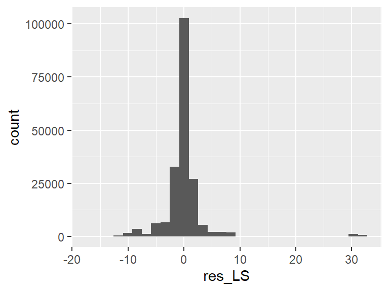

Histograms of the sampled residuals for LS.

```r
df_PA2 = data.frame(res_LS = boot1$resiudals_LS, res_LA = boot1$resiudals_LA)
ggplot(data = df_PA2) + geom_histogram(aes(x = res_LS))
```

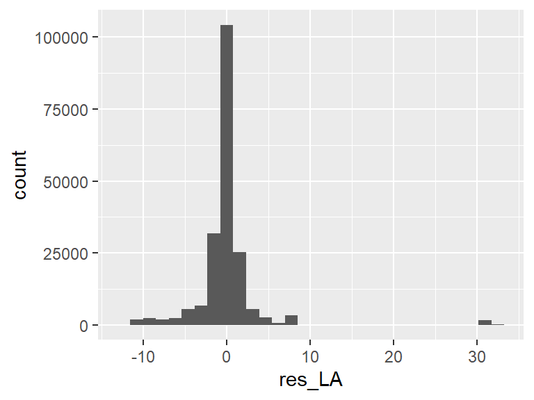

Histograms of the sampled residuals for LA.

```r
ggplot(data = df_PA2) + geom_histogram(aes(x = res_LA))
```

```r
#computing prediction interval for LS
q_x101_LS = stats::quantile(x = boot1$x101_LS, probs = c(0.025, 0.975))

#computing prediction interval for LS
q_x101_LA = stats::quantile(x = boot1$x101_LA, probs = c(0.025, 0.975))

df_x101 = data.frame(ls = boot1$x101_LS, la = boot1$x101_LA, q_LS = q_x101_LS, q_LA = q_x101_LA)

print(df_x101$q_LS[1:2])
```

```
## [1]  7.386229 22.312919
```

```r
print(paste0("The 95% prediction interval for LS is ", q_x101_LS[1], " to ", q_x101_LS[2]))
```

```
## [1] "The 95% prediction interval for LS is 7.38622894794466 to 22.3129185493858"
```

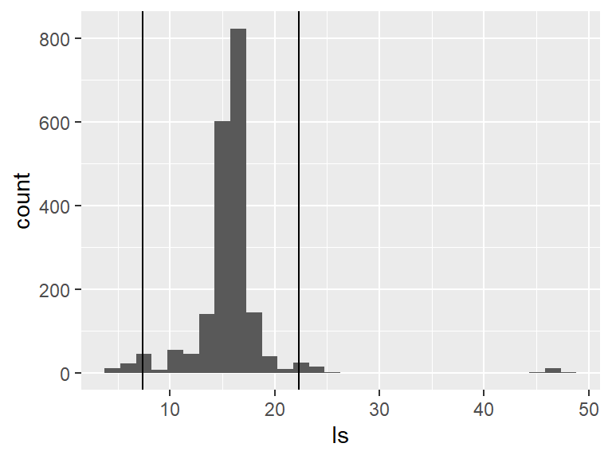

Plot of the $x_{101}$’s simulated by LS.

```r
ggplot(data = df_x101) + geom_histogram(aes(x = ls)) +
  geom_vline(xintercept = df_x101$q_LS[1], show.legend = TRUE) +
  geom_vline(xintercept = df_x101$q_LS[2], show.legend = TRUE ) +
  guides(color = q_x101_LS)
```

```r
print(paste0("The 95% prediction interval for LA is ", q_x101_LA[1], " to ", q_x101_LA[2]))
```

```
## [1] "The 95% prediction interval for LA is 8.11248079169294 to 22.8630903543515"
```

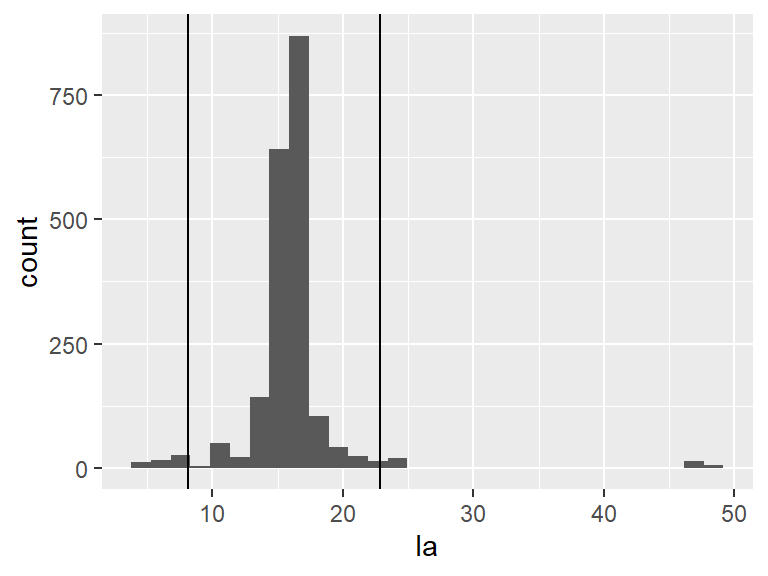

Plot of the $x_{101}$’s simulated by LA

```r
ggplot(data = df_x101) + geom_histogram(aes(x = la)) +
  geom_vline(xintercept = df_x101$q_LA[1], show.legend = TRUE ) +
  geom_vline(xintercept = df_x101$q_LA[2], show.legend = TRUE )
```

After calculating the $95\%$ prediction interval of the values of $x_{101}$ we can compare with the empricial distribution function defined:
$$\begin{equation}
\hat{F} = \sum_{i=1}^{n}\frac{1}{n}1(x_i \leq x)
\end{equation}$$

where $1(\cdot)$ is the indicator function. This is implemented in the code below:

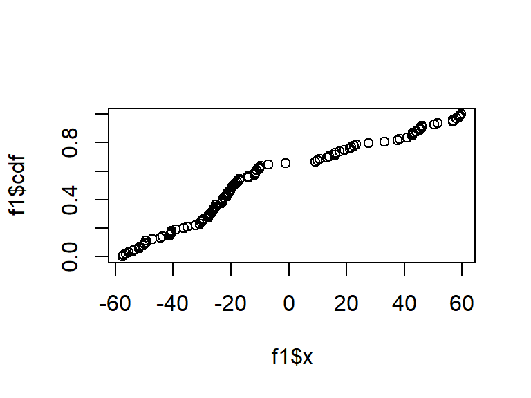

```r
emp_CDF = function(x){
  n = length(x)
  x_sorted = sort(x)
  F_hat = seq(0,n, length.out = n)/n
  return(list(x = x_sorted, cdf = F_hat))
}

f1 = emp_CDF(data3A$x)
plot(f1$x, f1$cdf)
```

# Problem B Permutation Test

In this task we look at data that contain measurements of the concentration of bilirubin (mg/dL) in blood samples taken from three young men. Bilirubin is a breakdown product of haemoglobin, which is a principal component of red blood cells. If the liver has suffered degeneration, if the decomposition of haemoglobin is elevated, or if the gall bladder has been destroyed, large amounts of bilirubin can accumulate in the blood, leading to jaundice. We will use the F-statistic to perform a Permutation test.

```r
# Fetching the data
df.bilirubin <- read.table("bilirubin.txt", header=T)
```

## 1)

To begin we fit a boxplot of the logarithms of concentrations for each individual.

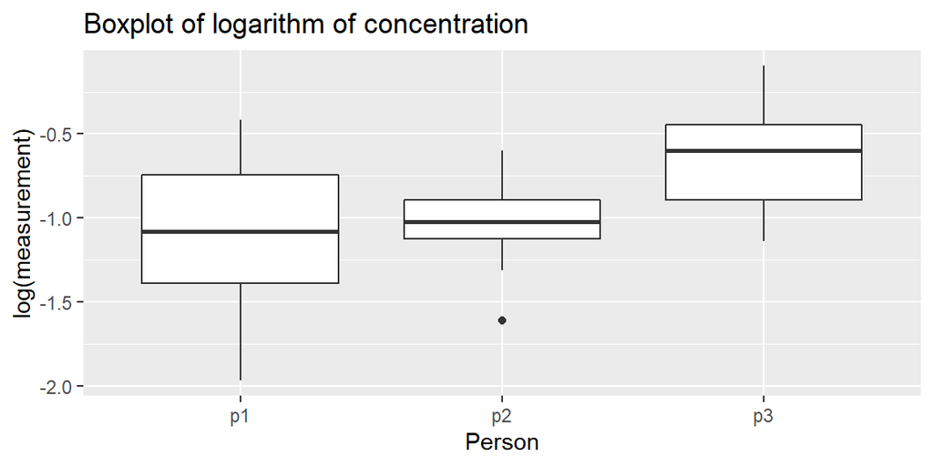

Boxplot for the logarithms of concentrations for each individual. The unit for the concentrations is $\textrm{mg/dL}$.

```r
# Plotting a boxplot for each person
ggplot(df.bilirubin, aes(x = pers, y = log(meas))) +
  geom_boxplot() +
  ggtitle("Boxplot of logarithm of concentration") +
  ylab("log(measurement)") +
  xlab("Person")
```

From Figure we observe that the measurements for person 3 differ quite drastically from the two other persons, while the measurements for person 1 and person 2 have approximately equal median. The measurements for person 1 does, however, appear to vary more than the measurements for person 2.

Next we fit the linear regression model

$$\begin{equation} \label{eq:model_B1}
\ln(Y_{i,j}) = \beta_i + \epsilon_{i,j}, \qquad \textrm{with } i = 1,2,3 \textrm{ and } j = 1, \dots, n_i
\end{equation}$$

where $n_1 = 11$, $n_2 = 10$ and $n_3 = 8$ and $\epsilon_{i,j} \sim \mathcal{N}(0, \sigma^2)$.

```r
model.bilirubin <- lm(log(meas)~pers, data=df.bilirubin)
summary.model.bilurbin = summary.lm(model.bilirubin)
```

Next we use the F-test to test the hypothesis $\beta_1 = \beta_2 = \beta_3$.

$$\begin{align*}
&\textrm{H$_0$: } \beta_1 = \beta_2 = \beta_3 \\
&\textrm{H$_1$: At least one $\beta_i$ is different from the other $\beta_i$s}
\end{align*}$$

We use significance level $\alpha = 0.05$ for the hypothesis test.

```r
Fval = summary.model.bilurbin$fstatistic
p.value = pf(Fval[names(Fval) == "value"], Fval[names(Fval) == "numdf"], Fval[names(Fval) == "dendf"],
             lower.tail = FALSE)
```

The F-statistic is $3.67$ with $(2, 26)$ degrees of freedom. The corresponding p-value is $0.0395$. As this p-value is lower than our chosen significance level $\alpha = 0.05$ we reject the null hypothesis and conclude that at least one $\beta_i$ is different from the other.

## 2)

```r
# Function that performs one iteration of the Permutation test
permTest = function(df) {
  # permute the data
  n = nrow(df)
  obs.shuffled = sample(1:n, n, replace = FALSE)
  df.shuffled = data.frame(meas = df$meas[obs.shuffled], pers =df$pers)
  # fit the model on the shuffled data
  model.shuffled <- lm(log(meas)~pers, data=df.shuffled)
  # calculate the F-statistic and return it
  fstatistic = summary.lm(model.shuffled)$fstatistic[1]
  return(fstatistic)
}
```

## 3)

In this task we perform a permutation test using the function to generate a sample of size 999 for the F-statistic.

```r
# Function for performing permutation test
permutation.test = function(df, Fval, B = 999, plot.hist = TRUE) {
  "
  Input:
  - df: data frame for which the permutation test should be performed
  - Fval: F-statistic calculated for the model fitted to the original dataset
  - B: number of generated bootstrap samples
  - plot.hist: Boolean determining whether a histogram of the estimated density function
  of the F-statistic under the null hypothesis should be plotted
  Output:
  - A list containing
    -- p.value: The estimated p-value for the permuation test
    -- fstatistic.vec
  "
  # Initialize vector for storing F-statistics
  fstatistic.vec = rep(NA, B)
  # Calculcate F-statistics from permutated datasets
  for (i in 1:B) fstatistic.vec[i] = permTest(df)
  # if hist == TRUE plot a histogram for the estimated density function of the F-statistic
  if (plot.hist) {
    fig.hist = ggplot(data.frame(fstatistic = fstatistic.vec), aes(x = fstatistic, y = ..density..)) +

      geom_histogram(bins = 50) + xlab("F-statistic") + ylab("Density") +

      ggtitle("Histogram of the F-statistic under the null hypothesis") +

      geom_vline(aes(xintercept=Fval, col = "F-statistic calculated from original dataset"), data = data.frame(Fval = Fval[1]), linetype = "dashed") +

      theme(legend.position = "bottom") + guides(col = guide_legend("Vertical line"))

    print(fig.hist)
  }
  # Calculate the p-value from the permutation test using the histogram as
  # an approximation for the distribution of the F-statistic
  p.value = sum(fstatistic.vec >= Fval) / B
  # Return the p-value and the simulated F-statistics under the null hypothesis
  return(list(p.value = p.value, fstatistic.vec = fstatistic.vec))
}
```

```r
set.seed(1)
p.value.permutation.test = permutation.test(df.bilirubin, Fval, B = 999)$p.value
```

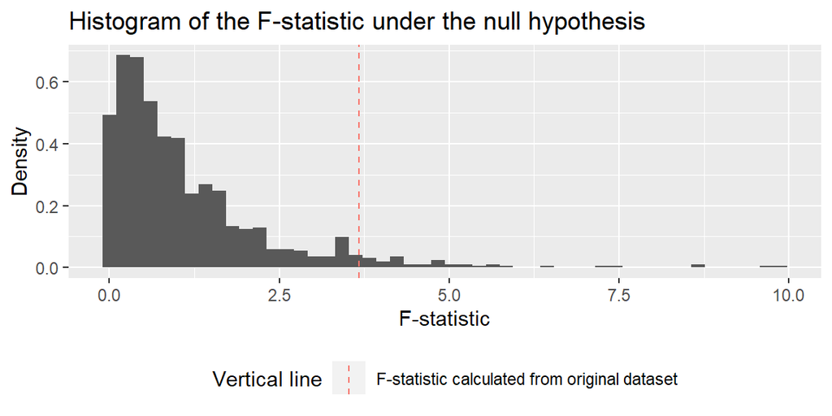

Histogram of estimated F-statistics during the Permutation test. The histogram approximates the density function of the F-statistic under the null hypothesis. The vertical, red, dashed line is the original F-statistic value.

In Figure we plot a histogram of the F-statistics computed during the Permutation test, which is an approximation for the density function of the F-statistic under the null hypothesis. From the plot it appears that the F-statistic computed from the original data is a part of the upper tail of the distribution function for the F-statistic under the null hypothesis.

# Problem C

Let $x_1, \dots, x_n$ and $y_1, \dots, y_n$ be independent random variables where the $x_i$’s have an exponential distribution with $\lambda_0$ and the $y_i$’s have an exponential distribution with intensity $\lambda_1$. Assume we do not observe $x_1, \dots, x_n$ and $y_1, \dots, y_n$ directly, but that we observe

$$\begin{align*}
z_i &= \max \{x_i, y_i\} \qquad \textrm{for } i = 1, \dots, n \\
u_i &= I(x_i \geq y_i) \qquad \textrm{for } i = 1, \dots, n
\end{align*}$$

where $I(A) = 1$ if $A$ is true and $0$ otherwise. Thus for each $i = 1, \dots, n$ we observe the largest value of $x_i$ and $y_i$ and we know whether the observed value is $x_i$ or $y_i$. Based on the observed $(z_i, u_i), \; i = 1, \dots, n$, we will in this problem use the EM algorithm to find the maximum likelihood estimates for $(\lambda_0, \lambda_1)$.

## a)

Define the following notation:

$$\begin{align*}
\ensuremath{\boldsymbol{\mathbf{x} }} = [x_1, \dots, x_n] \\
\ensuremath{\boldsymbol{\mathbf{y} }} = [y_1, \dots, y_n] \\
\ensuremath{\boldsymbol{\mathbf{z} }} = [z_1, \dots, z_n] \\
\ensuremath{\boldsymbol{\mathbf{u} }} = [u_1, \dots, u_n]
\end{align*}$$

The likelihood function for the complete data $(\ensuremath{\boldsymbol{\mathbf{x} }}, \ensuremath{\boldsymbol{\mathbf{y} }})$ is

$$\begin{align*}
L(\lambda_0, \lambda_1 | \ensuremath{\boldsymbol{\mathbf{x} }}, \ensuremath{\boldsymbol{\mathbf{y} }})
&= f(\ensuremath{\boldsymbol{\mathbf{x} }}, \ensuremath{\boldsymbol{\mathbf{y} }} | \lambda_0, \lambda_1) \\
&= f(\ensuremath{\boldsymbol{\mathbf{x} }} | \lambda_0) f(\ensuremath{\boldsymbol{\mathbf{y} }} | \lambda_1) \\
&= \left [ \prod_{i=1}^n f(x_i | \lambda_0) \right ] \left [ \prod_{i=1}^n f(y_i | \lambda_1) \right ]
&= \left [ \prod_{i=1}^n \lambda_0 e^{- \lambda_0 x_i} \right ]
\left [ \prod_{i=1}^n \lambda_1 e^{- \lambda_1 y_i} \right ] \\
&= \lambda_0^n e^{-\lambda_0 \sum_{i=1}^n x_i} \lambda_1^n e^{-\lambda_1 \sum_{i=1}^n y_i}.
\end{align*}$$

Correspondingly, the log likelihood function for the complete data $(\ensuremath{\boldsymbol{\mathbf{x} }}, \ensuremath{\boldsymbol{\mathbf{y} }})$ is

$$\begin{equation*}
\begin{split}
l(\lambda_0, \lambda_1 | \ensuremath{\boldsymbol{\mathbf{x} }}, \ensuremath{\boldsymbol{\mathbf{y} }}) &= \ln \left( L(\lambda_0, \lambda_1 | \ensuremath{\boldsymbol{\mathbf{x} }}, \ensuremath{\boldsymbol{\mathbf{y} }}) \right) \\
&= n \left( \ln(\lambda_0) + \ln(\lambda_1) \right) -\lambda_0 \sum_{i=1}^n x_i -\lambda_1 \sum_{i=1}^n y_i
\end{split}
\end{equation*}$$

Using this we want to find the expectation of the log likelihood function for the complete data condtional on the observed data $(\ensuremath{\boldsymbol{\mathbf{z} }}, \ensuremath{\boldsymbol{\mathbf{u} }})$ and the estimates for the parameters at iteration $t$, i.e $(\lambda_o^{(t)}, \lambda_1^{(t)})$.

$$\begin{equation} \label{eq:em_formula_incomplete}
\begin{split}
\textrm{E}\left[ l(\lambda_0, \lambda_1 | \ensuremath{\boldsymbol{\mathbf{x} }}, \ensuremath{\boldsymbol{\mathbf{y} }}) | \ensuremath{\boldsymbol{\mathbf{z} }}, \ensuremath{\boldsymbol{\mathbf{u} }}, \lambda_0^{(t)}, \lambda_1^{(t)}\right]
&= \textrm{E}\left[ \ln\left( f(\ensuremath{\boldsymbol{\mathbf{x} }}, \ensuremath{\boldsymbol{\mathbf{y} }} | \lambda_0, \lambda_1) \right)
| \ensuremath{\boldsymbol{\mathbf{z} }}, \ensuremath{\boldsymbol{\mathbf{u} }}, \lambda_0^{(t)}, \lambda_1^{(t)} \right] \\
&= n \left( \ln(\lambda_0) + \ln(\lambda_1) \right) -\lambda_0 \sum_{i=1}^n \textrm{E}[x_i | z_i, u_i, \lambda_0^{(t)}] - \lambda_1 \sum_{i=1}^n \textrm{E}[y_i | z_i, u_i, \lambda_1^{(t)}
\end{split}
\end{equation}$$

For the case $u_i = 1$ then we have

$$\begin{align*}
\textrm{E}[x_i | z_i, u_i = 1, \lambda_0^{(t)}] &= u_i
\end{align*}$$

and

$$\begin{align*}
\textrm{E}[y_i | z_i, u_i = 1, \lambda_1^{(t)}
&= \int_0^{z_i} y_i P \left( y_i | y_i \leq z_i, \lambda_1^{(t)}\right) dy_i \\
&=\int_0^{z_i} y_i \frac{P \left( y_i \cap y_i \leq z_i | \lambda_1^{(t)} \right) }
{P \left( y_i \leq z_i | \lambda_1^{(t)} \right) } dy_i \\
&= \int_0^{z_i} y_i \frac{f(y_i | \lambda_1^{(t)})}{ \int_0^{z_i} f(y_i^* | \lambda_1^{(t)}) dy_i^*} dy_i) \\
&= \frac{1}{ \int_0^{z_i} \lambda_1^{(t)} e^{-\lambda_1^{(t)} y_i^* } dy_i^*}
\int_0^{z_i} y_i \lambda_1^{(t)} e^{-\lambda_1^{(t)} y_i} dy_i) \\
&= \frac{1}{1 - e^{- \lambda_1^{(t)} z_i}}
\left(
-z_i e^{- \lambda_1^{(t)} z_i} - \frac{1}{\lambda_1^{(t)}} e^{- \lambda_1^{(t)} z_i} + \frac{1}{\lambda_1^{(t)}}
\right) \\
&= \frac{-z_i e^{- \lambda_1^{(t)} z_i}}{1 - e^{- \lambda_1^{(t)} z_i}} + \frac{1}{\lambda_1^{(t)}} \\
&= \frac{1}{\lambda_1^{(t)}} - \frac{z_i}{e^{\lambda_1^{(t)} z_i} - 1}
\end{align*}$$

Correspondlingly, we have for the $u_i = 0$ that

$$\begin{align*}
\textrm{E}[x_i | z_i, u_i = 0, \lambda_0^{(t)}
&= \int_0^{z_i} x_i P \left( x_i | x_i \leq z_i, \lambda_0^{(t)}\right) dx_i \\
&=\int_0^{z_i} x_i \frac{P \left( x_i \cap x_i \leq z_i | \lambda_0^{(t)} \right) }
{P \left( x_i \leq z_i | \lambda_0^{(t)} \right) } dx_i \\
&= \int_0^{z_i} x_i \frac{f(x_i | \lambda_0^{(t)})}{ \int_0^{z_i} f(x_i^* | \lambda_0^{(t)}) dx_i^*} dx_i) \\
&= \frac{1}{ \int_0^{z_i} \lambda_0^{(t)} e^{-\lambda_0^{(t)} x_i^* } dx_i^*}
\int_0^{z_i} x_i \lambda_0^{(t)} e^{-\lambda_0^{(t)} x_i} dx_i) \\
&= \frac{1}{1 - e^{- \lambda_0^{(t)} z_i}}
\left(
-z_i e^{- \lambda_0^{(t)} z_i} - \frac{1}{\lambda_0^{(t)}} e^{- \lambda_0^{(t)} z_i} + \frac{1}{\lambda_0^{(t)}}
\right) \\
&= \frac{-z_i e^{- \lambda_0^{(t)} z_i}}{1 - e^{- \lambda_0^{(t)} z_i}} + \frac{1}{\lambda_0^{(t)}} \\
&= \frac{1}{\lambda_0^{(t)}} - \frac{z_i}{e^{\lambda_0^{(t)} z_i} - 1}
\end{align*}$$

and

$$\begin{align*}
\textrm{E}[y_i | z_i, u_i = 0, \lambda_1^{(t)}] &= u_i \\
\end{align*}$$

$$\begin{equation} \label{eq:em_formula}
\begin{split}
\textrm{E}\left[ l(\lambda_0, \lambda_1 | \ensuremath{\boldsymbol{\mathbf{x} }}, \ensuremath{\boldsymbol{\mathbf{y} }}) \big | \ensuremath{\boldsymbol{\mathbf{z} }}, \ensuremath{\boldsymbol{\mathbf{u} }}, \lambda_0^{(t)}, \lambda_1^{(t)}\right]
=& \textrm{E}\left[ \ln\left( f(\ensuremath{\boldsymbol{\mathbf{x} }}, \ensuremath{\boldsymbol{\mathbf{y} }} | \lambda_0, \lambda_1) \right)
\big | \ensuremath{\boldsymbol{\mathbf{z} }}, \ensuremath{\boldsymbol{\mathbf{u} }}, \lambda_0^{(t)}, \lambda_1^{(t)} \right] \\
=& n \left( \ln(\lambda_0) + \ln(\lambda_1) \right) \\
&- \lambda_0 \sum_{i=1}^n
\left [ u_i z_i
+ (1 - u_i) \left( \frac{1}{\lambda_0^{(t)}} - \frac{z_i}{e^{\lambda_0^{(t)} z_i} - 1} \right)
\right] \\
&- \lambda_1 \sum_{i=1}^n \left [
(1 - u_i) z_i +
u_i \left( \frac{1}{\lambda_1^{(t)}} - \frac{z_i}{e^{\lambda_1^{(t)} z_i} - 1} \right)
\right ]
\end{split}
\end{equation}$$

## 2)

Let $Q(\lambda_0, \lambda_1)$ be defined

$$\begin{equation*}
Q(\lambda_0, \lambda_1)
= Q(\lambda_0, \lambda_1 | \lambda_0^{(t)}, \lambda_1^{(t)})
= \textrm{E}\left[ l(\lambda_0, \lambda_1 | \ensuremath{\boldsymbol{\mathbf{x} }}, \ensuremath{\boldsymbol{\mathbf{y} }}) \big | \ensuremath{\boldsymbol{\mathbf{z} }}, \ensuremath{\boldsymbol{\mathbf{u} }}, \lambda_0^{(t)}, \lambda_1^{(t)}\right]
\end{equation*}$$

In Task C1 we found an expression for $Q(\lambda_0, \lambda_1)$. To be able to implement Algorithm we need to find an expression for $\textrm{argmax}_{(\lambda_0, \lambda_1)} Q(\lambda_0, \lambda_1)$. To maximize $Q(\lambda_0, \lambda_1)$ with respect to $(\lambda_0, \lambda_1)$ we set the partial derivatives equal to zero and solve for each of the parameters.

$$\begin{align}
\frac{\partial}{\partial \lambda_0} Q(\lambda_0, \lambda_1) = 0 \nonumber \\
\frac{n}{\lambda_0} - \sum_{i=1}^n \left[ u_i z_i
+ (1 - u_i) \left( \frac{1}{\lambda_0^{(t)}} - \frac{z_i}{\exp \{ \lambda_0^{(t)} z_i \} - 1} \right) \right ] = 0 \nonumber \\
\lambda_0 = \frac{n}
{\sum_{i=1}^n \left[ u_i z_i
+ (1 - u_i) \left( \frac{1}{\lambda_0^{(t)}} - \frac{z_i}{\exp \{ \lambda_0^{(t)} z_i \} - 1} \right) \right ]} \label{eq:recursive_lambda0}
\end{align}$$

$$\begin{align}
\frac{\partial}{\partial \lambda_1} Q(\lambda_1, \lambda_1) = 0 \nonumber \\
\frac{n}{\lambda_1} - \sum_{i=1}^n \left[ (1 - u_i) z_i
+ u_i \left( \frac{1}{\lambda_1^{(t)}} - \frac{z_i}{\exp \{ \lambda_1^{(t)} z_i \} - 1} \right) \right ] = 0
\nonumber \\
\lambda_1 = \frac{n}
{\sum_{i=1}^n \left[ (1-u_i) z_i
+ u_i \left( \frac{1}{\lambda_1^{(t)}} - \frac{z_i}{\exp \{ \lambda_1^{(t)} z_i \} - 1} \right) \right ]} \label{eq:recursive_lambda1}
\end{align}$$

To ensure we have found a maximum we also check the second derivatives

$$\begin{align*}
\frac{\partial^2}{\partial \lambda_0^2} &= \frac{-n}{\lambda_0^2} < 0\\
\frac{\partial^2}{\partial \lambda_1^2} &= \frac{-n}{\lambda_1^2} < 0
\end{align*}$$

Below we implement the EM-algorithm for this specific case and find the maximum likelihood estimates when the data is as specified in the files and available from the course home page. As stopping criteria we use that the maximum absolute value parameter change from one iteration to the next must be smaller than some chosen $\epsilon$, that is $\max \left \{ |\lambda_0^{(t+1)} - \lambda_0^{(t)}|, |\lambda_1^{(t+1)} - \lambda_1^{(t)}| \right \} < \epsilon$.

```r
# implementation of the EM algorithm.
# Function for finding maximum likelihood estimates of lambda0 and lambda1
em.algorithm = function(z, u, lambda0, lambda1, epsilon = 1e-6) {
  # initialize delta as higher than stopping critera
  delta = 1 + epsilon
  # create vectors for storing lambda0 and lambda1 values for each iteration
  lambda0.vec = c(lambda0)
  lambda1.vec = c(lambda1)
  # calculate the length of z for use in the argmax expressions
  n = length(z)
  t = 1
  while (delta > epsilon) {
    # calculate new lambda0 and lambda1 values
    lambda0.vec = c(lambda0.vec,
                       n / sum(u * z + (1 - u) * (1 / lambda0.vec[t] - z / (exp(lambda0.vec[t] * z) - 1) ) )
    )
    lambda1.vec = c(lambda1.vec,
                    n / sum((1 - u) * z + u * (1 / lambda1.vec[t] - z / (exp(lambda1.vec[t] * z) - 1) ) )
    )
    t = t + 1

    # update delta to check if stopping criteria is satisfied
    delta = max(abs(lambda0.vec[t] - lambda0.vec[t-1]), abs(lambda1.vec[t] - lambda1.vec[t-1]))
  }
  # get the number of iterations
  n.iter = t-1
  # create a data frame for storing parameter values for each iteration for easy plotting
  df = data.frame(iter = seq(0,n.iter), lambda0 = lambda0.vec, lambda1 = lambda1.vec)
  # same data frame on long format (also for easy plotting)
  df.long = pivot_longer(df, -iter, names_to = "Parameter")
  # return a list with useful values
  return ( list(lambda0 = lambda0.vec[t],lambda1 = lambda1.vec[t],
                lambda0.vec = lambda0.vec, lambda1.vec = lambda1.vec, n.iter = n.iter,
                df = df, df.long = df.long))
}
```

```r
# fetch the data
z = read.csv("z.txt")[,1]
u = read.csv("u.txt")[,1]
# find maximum likelihood estimates
result.em = em.algorithm(z, u, 1, 1)
```

The maximum likelihood estimates of $(\lambda_0, \lambda_1)$ are $(\hat \lambda_0, \hat \lambda_1) = (3.463, 9.335)$. Next we test the convergence of the algorithm for different initial values.

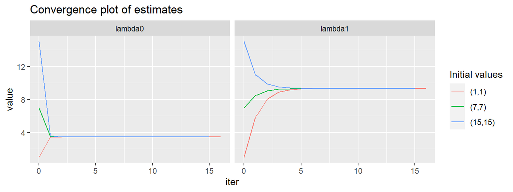

Visualization of convergence for each of the parameters $(\lambda_0,\lambda_1)$ for three different initial values $(\lambda_0^{(0)}, \lambda_1^{(0)}) \in [(1,1), (7,7), (15, 15)]$. As stopping criteria we use $\textrm{max} [ |\lambda_0^{(t+1)} - \lambda_0^{(t)}|, |\lambda_1^{(t+1)} - \lambda_1^{(t)}| ] < 10^{-6}$.

```r
# test for different initial values
# choose the initial value combinations
initial.lambda0 = c(1, 7, 15)
initial.lambda1 = c(1, 7, 15)

# create a data frame to store all the realizations
df.em.long = data.frame()
for (i in 1:length(initial.lambda0)) {
  result.em.i = em.algorithm(z, u, initial.lambda0[i], initial.lambda1[i])
  df.em.long = rbind(df.em.long, cbind(result.em.i$df.long, "initial.value" = toString(i)))
}
# visialize convergence for different initial values
ggplot(df.em.long, aes(x = iter, y = value, col = initial.value)) + geom_line() +

  facet_wrap(~Parameter) + guides(col = guide_legend("Initial values")) +

  scale_color_discrete(labels = c("(1,1)", "(7,7)", "(15,15)")) +

  ggtitle("Convergence plot of estimates")
```

From Figure we see that the algorithm quickly converges for all three initial conditions. The estimate for $\lambda_0$ appear to be almost converged after only a single iteration, while the estimate for $\lambda_1$ seem to need around 5 iterations for the same level of precicion. After 16 iterations all three initial positions were converged according to $\epsilon = 10^{-6}$.

## 3)

$$\begin{align*}
\widehat {\textrm{SD}}_{B}[\hat \lambda_0] &= \sqrt{\frac{1}{B-1} \sum_{b=1}^B (\lambda_0^{b*} -\bar \lambda_0^*)^2} \\
\widehat {\textrm{SD}}_{B}[\hat \lambda_1] &= \sqrt{\frac{1}{B-1} \sum_{b=1}^B (\lambda_1^{b*} -\bar \lambda_1^*)^2} \\
\widehat {\textrm{Corr}}_{B}[\hat \lambda_0, \hat \lambda_1] &= \sqrt{\frac{1}{B-1}
\sum_{b=1}^B (\lambda_0^{b*} -\bar \lambda_0^*)(\lambda_1^{b*} -\bar \lambda_1^*)}
\end{align*}$$

where

$$\begin{align*}
\bar \lambda_0^* &= \frac{1}{B} \sum_{b=1}^{B} \lambda_0^{b*} \\
\bar \lambda_1^* &= \frac{1}{B} \sum_{b=1}^{B} \lambda_1^{b*}.
\end{align*}$$

Additionally, we can calculate an estimate for the biases of $\hat \lambda_0$ and $\hat \lambda_1$ using the expressions below.

$$\begin{equation} \label{eq:bias}
\begin{split}
\widehat {\textrm{Bias}}_B [\hat \lambda_0] &= \hat \lambda_0 - \bar \lambda_0^{*} \\
\widehat {\textrm{Bias}}_B [\hat \lambda_1] &= \hat \lambda_1 - \bar \lambda_1^{*}
\end{split}
\end{equation}$$

$$\begin{equation*}
\widehat {\textrm{Bias}}_{B, \textrm{improved}}[\hat \lambda_0, \hat \lambda_1] = \hat {R}((\ensuremath{\boldsymbol{\mathbf{Z} }}, \ensuremath{\boldsymbol{\mathbf{U} }}), F) = \frac{1}{B} \sum_{b=1}^B \left( T(\hat F^{b*}) - T(\hat \bar F^*) \right)
= \bar \theta^* - T(\bar F^*)
\end{equation*}$$

where

$$\begin{equation*}
\bar F^* = \frac{1}{B} \sum_{b=1}^B \hat F^{b*}
\end{equation*}$$

and $\bar \theta^* = (\bar \lambda_0^*, \bar \lambda_1^*)$.

Let $T_{\lambda_0}(F) = \lambda_0$ and $T_{\lambda_1}(F) = \lambda_1$. Then $T(\bar F^*)$ can be calculated through the EM algorithm with each step being

$$\begin{align*}
\lambda_0 &= \frac{n} {\frac{1}{B} \sum_{b=1}^B \sum_{i=1}^n \left[ u_i^{b*} z_i^{b*}
+ (1 - u_i^{b*}) \left( \frac{1}{\lambda_0^{(t)}} - \frac{z_i^{b*}}{\exp \{ \lambda_0^{(t)} z_i^{b*} \} - 1} \right) \right]} \\
\lambda_1 &= \frac{n}{\frac{1}{B} \sum_{b=1}^B \sum_{i=1}^n \left[ (1-u_i^{b*}) z_i^{b*}
+ u_i^{b*} \left( \frac{1}{\lambda_1^{(t)}} - \frac{z_i^{b*}}{\exp \{ \lambda_1^{(t)} z_i^{b*} \} - 1} \right) \right ]}
\end{align*}$$

The derivation for this is not included, but is quite similar to how Equation () and () were derived.

```r
# fast implementation of the EM algorithm that only stores and returns
# the final values of lambda0 and lambda1.
# Function for finding maximum likelihood estimates of lambda0 and lambda1
fast.em.algorithm = function(z, u, lambdas.initial, epsilon = 1e-6) {
  # initialize delta as higher than stopping critera
  delta = 1 + epsilon
  # Create variable for storing previous iteration value of lambda0 and lambda1 values for each iteration
  lambda0.prev = lambdas.initial[1]
  lambda1.prev = lambdas.initial[2]
  # calculate the length of z for use in the argmax expressions
  n = length(z)
  while (delta > epsilon) {
    # calculate new lambda0 and lambda1 values
    lambda0 = n / sum(u * z + (1 - u) * (1 / lambda0.prev - z / (exp(lambda0.prev * z) - 1) )
    )
    lambda1 = n / sum((1 - u) * z + u * (1 / lambda1.prev - z / (exp(lambda1.prev * z) - 1) )
    )

    # update delta to check if stopping criteria is satisfied
    delta = max(abs(lambda0 - lambda0.prev), abs(lambda1 - lambda1.prev))

    # update previous iteration value of lamba0 and lambda1 with newly calculated values
    lambda0.prev = lambda0
    lambda1.prev = lambda1
  }
  # return final estimates for lambda0 and lambda1
  return ( c(lambda0, lambda1))
}
```

```r
# function for performing what is described in the bootstrap algorithm
bootstrap.lambdas = function(z, u, B = 1000, initial.lambda0 = 1, initial.lambda1 = 1, epsilon = 1e-6) {
  "
  Input:
  - z: observed data as defined earlier (max of x_i and y_i, for i = 1,...,n)
  - u: observed data as defined earlier (1 if x_i >= y_i else 0, for i = 1, ...,n)
  - B: number of bootstrapped samples to use
  - initial.lambda0: initial value for lambda0 for use in em algorithm
  - initial.lambda1 initial value for lambda1 for use in em algorithm
  Output:
  - A list containing
    -- lambda0.est: maximum likelihood estimate for lambda0
    -- lambda1.est: maximum likelihood estimate for lambda1
    -- lambda0.bootstrap.mean: mean of maximum likelihood estimators for lambda0 based
    on bootstrapped data.
    -- lambda1.bootstrap.mean: mean of maximum likelihood estimators for lambda1 based
    on bootstrapped data.
    -- lambda0.bias.est: estimate of bias for lambda0 estimate
    -- lambda1.bias.est: estimate of bias for lambda1 estimate
    -- lambda0.bias.est.improved: improvedestimate of bias for lambda0 estimate
    -- lambda1.bias.est.improved: improvd estimate of bias for lambda1 estimate
    -- corr.lambda0.lambda1: esimate for the correlation between lambda0 and lambda1 estimators
  "


  # initialize matrix for store bootstrapped lambda0 and lambda1 estimates
  lambdas.bootstrap = matrix(NA, ncol = 2, nrow = B+1)
  # the first row is only used for initializing the algorithm and will later be removed
  lambdas.bootstrap[1,] = c(initial.lambda0, initial.lambda1)
  n = length(z)
  # initialize vectors for storing all bootstraped data
  z.bootstrap.all = rep(NA, B*n)
  u.bootstrap.all = rep(NA, B*n)
  for (i in 1:B) {
    # draw which observations should be used
    drawn.obs = sample(1:n, n, replace=TRUE)
    # create new bootstrapped datasets
    z.bootstrap = z[drawn.obs]
    u.bootstrap = u[drawn.obs]
    # using the bootstrapped data, calculate the maximum likelihood estimates of
    # lambda0 and lambda1 using em algorithm
    lambdas.bootstrap[i+1,] = fast.em.algorithm(z.bootstrap, u.bootstrap,
                                                lambdas.bootstrap[i,], epsilon)
    # store the bootstrapped datasets
    z.bootstrap.all[(1+n*(i-1)):(n*i)] = z.bootstrap
    u.bootstrap.all[(1+n*(i-1)):(n*i)] = u.bootstrap

  }
  # removing the initial values from the lambdas matrix
  lambdas.bootstrap = lambdas.bootstrap[-1,]

  # calculating the mean of the bootstrapped estimators of lambda0 and lambda1
  lambdas.bootstrap.mean = apply(lambdas.bootstrap, 2, mean)
   # calculating the standard deviation of the bootstrapped estimators of lambda0 and lambda1
  lambdas.bootstrap.sd = apply(lambdas.bootstrap, 2, sd)

  # calculate estimates for lambda0 and lambda1 using original observed data
  lambdas.est = fast.em.algorithm(z, u, lambdas.bootstrap.mean, epsilon)

    # calculate T(\bar F^*) for use to calculate improved bias estimates
  lambdas.est.from.mean.cumulative.dist = fast.em.algorithm(z.bootstrap.all, u.bootstrap.all,
                                                            c(1,1), epsilon)

  return(list(lambda0.est = lambdas.est[1],

              lambda1.est = lambdas.est[2],

              lambda0.bootstrap.mean = lambdas.bootstrap.mean[1],

              lambda1.bootstrap.mean = lambdas.bootstrap.mean[2],

              lambda0.bias.est = lambdas.bootstrap.mean[1] - lambdas.est[1],

              lambda1.bias.est = lambdas.bootstrap.mean[2] - lambdas.est[2],

              lambda0.bias.est.improved = lambdas.bootstrap.mean[1] -

                lambdas.est.from.mean.cumulative.dist[1],

              lambda1.bias.est.improved = lambdas.bootstrap.mean[2] -

                lambdas.est.from.mean.cumulative.dist[2],

              lambda0.bootstrap.sd = lambdas.bootstrap.sd[1],

              lambda1.bootstrap.sd = lambdas.bootstrap.sd[2],

              corr.lambda0.lambda1 = corr(lambdas.bootstrap)
              ))
}

set.seed(1)
result.bootstrap = bootstrap.lambdas(z, u, B = 2000, epsilon = 1e-6)
```

$$\begin{align*}
\hat \lambda_0^c &= \hat \lambda_0 - \widehat {\textrm{Bias}}_{B,\textrm{improved}}[\hat \lambda_0] \\
&= 3.4631 - 0.0174 \\
&= 3.4457 \\
\hat \lambda_1^c &= \hat \lambda_1 - \widehat {\textrm{Bias}}_{B,\textrm{improved}}[\hat \lambda_1] \\
&= 9.3349 - 0.0821 \\
&= 9.2528
\end{align*}$$

As the bias estimates are quite small compared to the estimates of $\lambda_0$ and $\lambda_1$ we prefer the maximum likelihood estimates $(\hat \lambda_0, \hat \lambda_1) = (3.4631, 9.3349)$ over the bias corrected estimates $(\hat \lambda_0^c, \hat \lambda_1^c) = (3.4457, 9.2528)$ since $\textrm{Var}[\hat \lambda_0^c] \geq \textrm{Var}[\hat \lambda_0]$ and $\textrm{Var}[\hat \lambda_1^c] \geq \textrm{Var}[\hat \lambda_1]$.

## 4)

An analytical formula for $f_{Z_i, U_i}(z_i, u_i | \lambda_0, \lambda_1)$ can be derived as

$$\begin{align*}
f_{Z_i, U_i}(z_i, u_i | \lambda_0, \lambda_1)
&= u_i \cdot P(x_i = z_i | \lambda_0) \cdot P(y_i \leq z_i | \lambda_1)
+ (1- u_i) P(x_i \leq z_i | \lambda_0) \cdot P(y_i = z_i | \lambda_0) \\
&= u_i \cdot \lambda_0 e^{-\lambda_0 z_i} \cdot \left[ \int_0^{z_i} \lambda_1 e^{- \lambda_1 y_i} dy_i \right]
+ (1 - u_i) \cdot \left[ \int_0^{z_i} \lambda_0 e^{- \lambda_0 x_i} dx_i\right] \cdot \lambda_1 e^{-\lambda_1 z_i} \\
&= u_i \cdot \lambda_0 e^{-\lambda_0 z_i} \cdot \left( 1 - e^{- \lambda_1 z_i} \right)
+ (1 - u_i) \cdot \left(1 - \lambda_0 e^{- \lambda_0 z_i} \right) \cdot \lambda_1 e^{-\lambda_1 z_i}
\end{align*}$$

The likelihood of $(\lambda_0, \lambda_1)$ given the observed data $(\ensuremath{\boldsymbol{\mathbf{z} }}, \ensuremath{\boldsymbol{\mathbf{u} }})$ is

$$\begin{align*}
L(\lambda_0, \lambda_1 | \ensuremath{\boldsymbol{\mathbf{z} }}, \ensuremath{\boldsymbol{\mathbf{u} }}) &= f_{\ensuremath{\boldsymbol{\mathbf{Z} }}, \ensuremath{\boldsymbol{\mathbf{U} }}}(\ensuremath{\boldsymbol{\mathbf{z} }}, \ensuremath{\boldsymbol{\mathbf{u} }} | \lambda_0, \lambda_1) \\
&= \prod_{i=1}^n f_{Z_i, U_i}(z_i, u_i | \lambda_0, \lambda_1) \\
&= \prod_{i=1}^n \left[
u_i \cdot \lambda_0 e^{-\lambda_0 z_i} \cdot \left( 1 - e^{- \lambda_1 z_i} \right)
+ (1 - u_i) \cdot \left(1 - \lambda_0 e^{- \lambda_0 z_i} \right) \cdot \lambda_1 e^{-\lambda_1 z_i}
\right]
\end{align*}$$

Since either $u_i = 1 \land (1-u_i) = 0$ or $u_i = 0 \land (1-u_i) = 1$ we have that the log likelihood of $(\lambda_0, \lambda_1)$ given the observed data $(\ensuremath{\boldsymbol{\mathbf{z} }}, \ensuremath{\boldsymbol{\mathbf{u} }})$ is

$$\begin{align*}
l(\lambda_0, \lambda_1 | \ensuremath{\boldsymbol{\mathbf{z} }}, \ensuremath{\boldsymbol{\mathbf{u} }}) &=
\log(L(\lambda_0, \lambda_1 | \ensuremath{\boldsymbol{\mathbf{z} }}, \ensuremath{\boldsymbol{\mathbf{u} }})) \\
&= \sum_{i=1}^n
\left(
u_i \left[ \ln(\lambda_0) - \lambda_0 z_i + \ln(1-e^{- \lambda_1 z_i}) \right]
+ (1 - u_i) \left[ \ln(1-e^{- \lambda_0 z_i}) + \ln(\lambda_1) - \lambda_1 z_i \right]
\right)
\end{align*}$$

The maximum likelihood estimators (MLE) are $(\hat \lambda_0, \hat \lambda_1) =\textrm{argmax}_{(\lambda_0, \lambda_1)} = L(\lambda_0, \lambda_1 | \ensuremath{\boldsymbol{\mathbf{z} }}, \ensuremath{\boldsymbol{\mathbf{u} }}) = \textrm{argmax}_{(\lambda_0, \lambda_1)} l(\lambda_0, \lambda_1 | \ensuremath{\boldsymbol{\mathbf{z} }}, \ensuremath{\boldsymbol{\mathbf{u} }})$. Unfortunately, it is not possible to find analytical formulas for the maximum likelihood estimators. We can, however, find the MLE numerically. An advantage of optimizing the likelihood directly compared to the EM algorithm is that when optimizing the likelihood directly the standard deviations of $\hat \lambda_0, \hat \lambda_1$ and the correlation between them is directly available without bootstrapping.

Let $\hat {\ensuremath{\boldsymbol{\mathbf{\lambda} }}} = [\hat \lambda_0, \hat \lambda_1]^T$. To get an estimate for $\textrm{Cov}[\hat {\ensuremath{\boldsymbol{\mathbf{\lambda} }}}]$ we use that for independent samples we have that asymptotically as the number of samples goes to infinity the maximum likelihood estimates have the distribution

$$\begin{equation*}
\hat {\ensuremath{\boldsymbol{\mathbf{\lambda} }}} \sim \mathcal{N}(\ensuremath{\boldsymbol{\mathbf{\lambda} }}, H(\ensuremath{\boldsymbol{\mathbf{\lambda} }})^{-1})
\end{equation*}$$

where $H$ is the observed Fisher matrix

$$\begin{equation*}
H(\ensuremath{\boldsymbol{\mathbf{\lambda} }}) = - \frac{\partial^2}{\partial \ensuremath{\boldsymbol{\mathbf{\lambda } }}\partial \ensuremath{\boldsymbol{\mathbf{\lambda} }}^T} l(\ensuremath{\boldsymbol{\mathbf{\lambda } }}| \ensuremath{\boldsymbol{\mathbf{z} }}, \ensuremath{\boldsymbol{\mathbf{u} }})
\end{equation*}$$

Below we optimize the log likelihood function $l(\lambda_0, \lambda_1 | \ensuremath{\boldsymbol{\mathbf{z} }}, \ensuremath{\boldsymbol{\mathbf{u} }})$ and use that $H(\ensuremath{\boldsymbol{\mathbf{\lambda} }}) \approx H(\hat {\ensuremath{\boldsymbol{\mathbf{\lambda} }}})$ to estimate standard deviations and correlations between the estimators $(\hat \lambda_0, \hat \lambda_1)$.

```r
# Create the log likelihood function that shall be optimized with respect to lambda0 and lambda1
log.likelihood = function(lambdas, z, u) {
  return(sum(u * (log(lambdas[1]) - lambdas[1] * z + log(1 - exp(-lambdas[2] * z)))
             + (1-u) * (log(1 - exp(-lambdas[1] * z)) + log(lambdas[2]) - lambdas[2] * z) ) )
}


initial.lambdas = c(1,1) # for initializaing the numerical search
set.seed(1) # set seed for reproducible results
# optimize the log likelihood function with respect to lambda0 and lambda1
# also calculate the Hessian matrix at the optimal values for lambda0 and lambda1
# use fnscale = -1 for maximization instead of minimization
# limit lambda0 and lambda1 to be larger than 0
optim.result = optim(initial.lambdas, log.likelihood, NULL, z, u, control = list(fnscale = -1), hessian=TRUE, lower=c(0,0))
# calculate the mle estimate of the covariance matrix of the estimators for [lambda0, lambda1]
cov.lambdas.mle = solve(- optim.result$hessian)
# print the mle estimate of the covariance matrix of the estimator for [lambda0, lambda1]
cov.lambdas.mle
```

```
##            [,1]      [,2]
## [1,] 0.06101972 0.0000000
## [2,] 0.00000000 0.6647234
```

```r
# calculate standard deviations and correlation between lambda0 and lambda1 estimators
lambda0.sd.mle = sqrt(cov.lambdas.mle[1,1])
lambda1.sd.mle = sqrt(cov.lambdas.mle[2,2])
corr.lambda0.lambda1.mle = cov.lambdas.mle[1,2] / (lambda0.sd.mle * lambda1.sd.mle)
```